# ExtraaLearn Project

### Observations on age

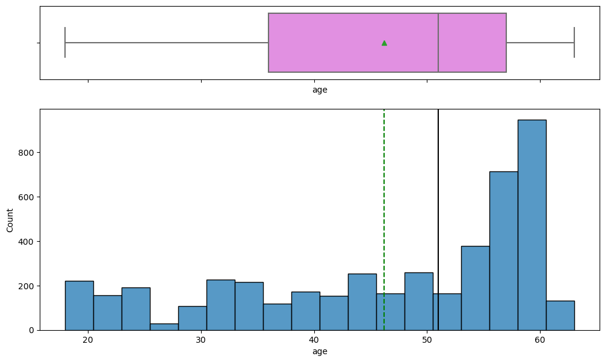

```python
histogram_boxplot(data, "age")
```

- Mean Age: 46.2
- Median Age: 51.0
- Standard Deviation Age: 13.16
- Minimum Age: 18
- Maximum Age: 63

### Observations on website_visits

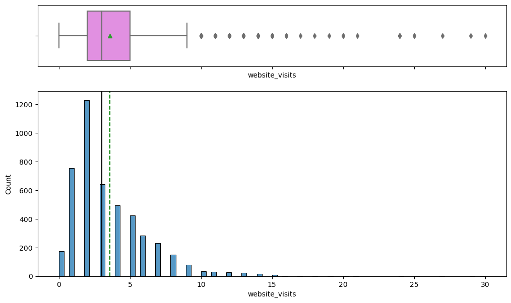

```python
histogram_boxplot(data, "website_visits") # Complete the code to plot a histogram_boxplot for website_visits
```

- Mean Website Visits: 3.57
- Median Website Visits: 3.0
- Standard Deviation Website Visits: 2.83
- Minimum Website Visits: 0
- Maximum Website Visits: 30

```python
# How many leads did not visit the website?
data[data["website_visits"] == 0].shape
```

```
(174, 14)
```

### Observations on number of time_spent_on_website

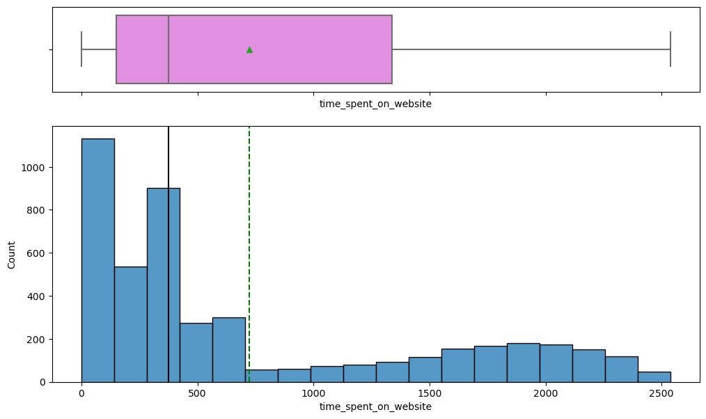

```python
histogram_boxplot(data, "time_spent_on_website") # Complete the code to plot a histogram_boxplot for time_spent_on_website
```

- Mean Time on Website: 12.07
- Median Time on Website: 6.27
- Standard Deviation Time on Website: 12.4
- Minimum Time on Website: 0.0
- Maximum Time on Website: 42.28

### Observations on number of page_views_per_visit

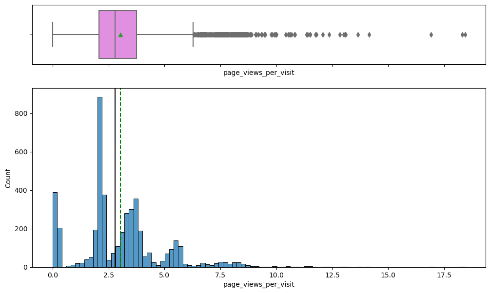

```python
histogram_boxplot(data, "page_views_per_visit") # Complete the code to plot a histogram_boxplot for page_views_per_visit
```

- Mean Pages per Visit: 3.03
- Median Pages per Visit: 2.79
- Standard Deviation Maximum Pages per Visit: 1.97
- Minimim Pages per Visit: 0.0
- Maximum Pages per Visit: 18.43

```python
# Function to create labeled barplots


def labeled_barplot(data, feature, perc=False, n=None):

    total = len(data[feature])
    count = data[feature].nunique()
    if n is None:
        plt.figure(figsize=(count + 1, 5))
    else:
        plt.figure(figsize=(n + 1, 5))

    plt.xticks(rotation=90, fontsize=15)
    ax = sns.countplot(
        data=data,
        x=feature,
        palette="Paired",
        order=data[feature].value_counts().index[:n].sort_values(),
    )

    for p in ax.patches:
        if perc == True:
            label = "{:.1f}%".format(
                100 * p.get_height() / total
            )
        else:
            label = p.get_height()

        x = p.get_x() + p.get_width() / 2
        y = p.get_height()

        ax.annotate(
            label,
            (x, y),
            ha="center",
            va="center",
            size=12,
            xytext=(0, 5),
            textcoords="offset points",
        )
    plt.show()
```

Explain the code:

The code is telling Python to use the feature (column) from the data dataframe to create a barplot. There is an option to have the results displayed as a percentage vs. a count. Since this is false, the results will be displayed as a count. The n will determine if the top n category levels should be displayed. If n is none, then all the levels will be displayed

- The length of the column is determined by the values taken from the feature column in the dataset.
- The next part of the code is telling Python to find the count of the unique values within that feature
- If n is none (as it is in this case) then the code is telling Python to make the size of the figure 1 value larger so all the values are clearly visible on the plot
- If n has been defined, then take the n value and add 1 to it to enlarge the size for the same reasons

  ```
    data=data,
    x=feature,
    palette="Paired",
    order=data[feature].value_counts().index[:n].sort_values(),
  ```

The rest of the code is telling Python that if the perc = true, then display the percent in the given format. If false, then display the count results from that feature

### Observations on current_occupation

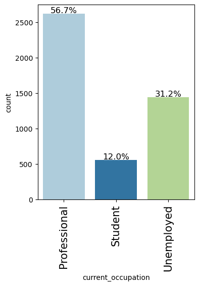

```python
labeled_barplot(data, "current_occupation", perc=True)
```

### Observations on number of first_interaction

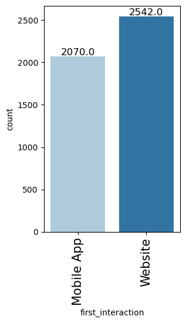

```python
labeled_barplot(data, "first_interaction")
```

### Observations on profile_completed

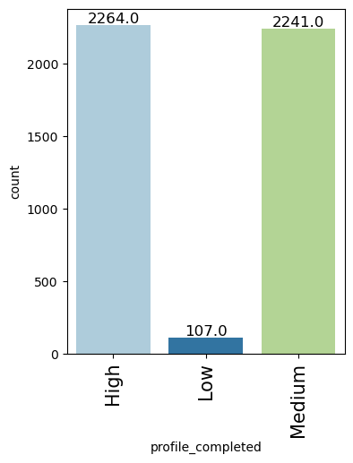

```python
labeled_barplot(data, "profile_completed")
```

### Observations on last_activity

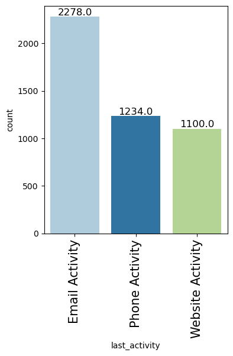

```python
labeled_barplot(data, "last_activity")
```

### Observations on print_media_type1

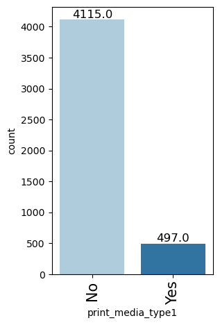

```python
labeled_barplot(data, "print_media_type1")
```

### Observations on print_media_type2

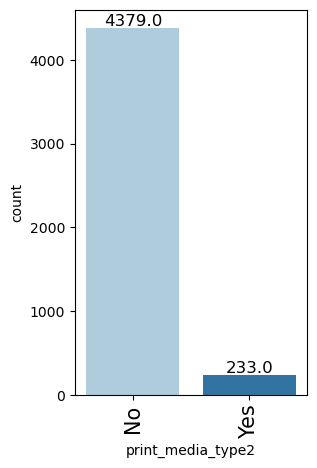

```python
labeled_barplot(data, "print_media_type2")
```

### Observations on digital_media

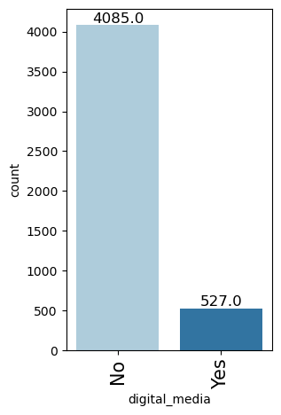

```python
labeled_barplot(data, "digital_media")
```

### Observations on educational_channels

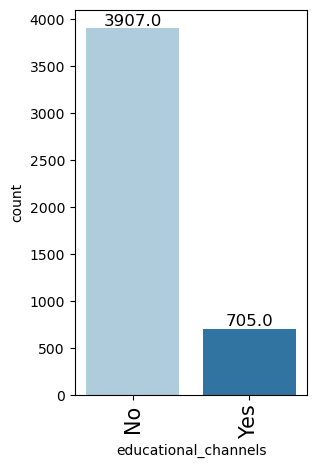

```python
labeled_barplot(data, "educational_channels")
```

### Observations on referral

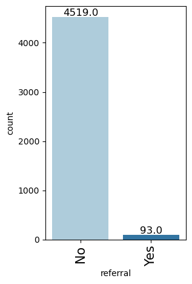

```python
labeled_barplot(data, "referral")
```

### Observations on status

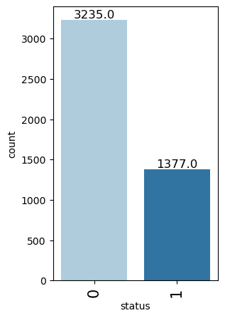

```python
labeled_barplot(data, "status")
```

**Observations from Univariate Analysis:**_****

The age of the leads range from 18 to 63 with an average of 46.2 years old. The median age is 51 with a non normal distribution of the age of the leads. The data is skewed left and less dispersed amongst leads over the age of 51.

The average time a lead spends on the website is just over 12 minutes with a standard deviation of 12.4 minutes. The amount of time is more dispersed after 10 minutes. This would be important information for ExtraaLearn to investigate and determine if the website is providing the most important information quickly to influence the leads to purchase.

The leads are averaging just over 3 web page views per visit with a maximum of just over 18. The data is heavily right skewed with a median of 2.79. The data also shows several outliers in the data. These outliers can indicate that the leads are generally not visiting more than a few pages in each visit to the website. This is also important for ExtraaLearn to understand and to design their web pages to provide the most impactful/influential information upfront so leads avoid having to research several pages to find the information they need.

### Bivariate Analysis

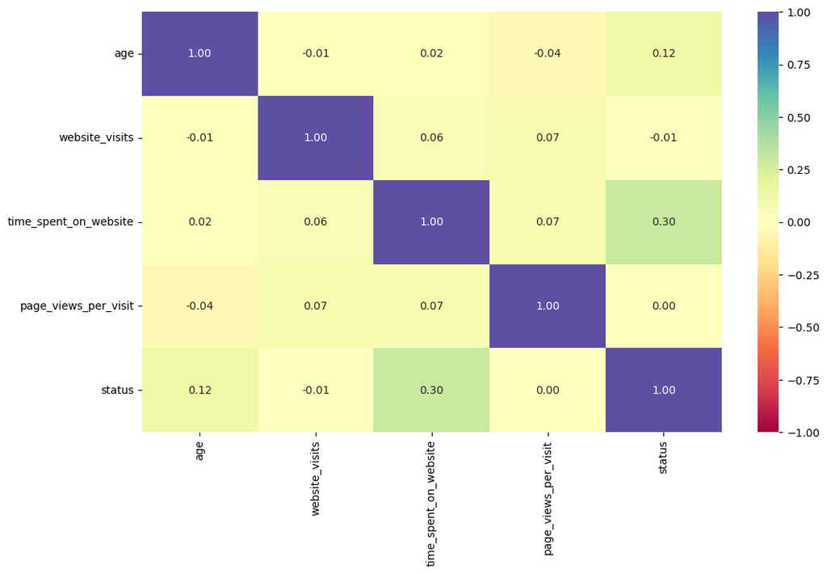

```python
cols_list = data.select_dtypes(include=np.number).columns.tolist()

plt.figure(figsize=(12, 7))
sns.heatmap(
    data[cols_list].corr(), annot=True, vmin=-1, vmax=1, fmt=".2f", cmap="Spectral"
)
plt.show()
```

**Creating functions that will help us with further analysis.**

```python
#Write a function to plot distributions wrt target


def distribution_plot_wrt_target(data, predictor, target):

    fig, axs = plt.subplots(2, 2, figsize=(12, 10))

    target_uniq = data[target].unique()

    axs[0, 0].set_title("Distribution of target for target=" + str(target_uniq[0]))
    sns.histplot(
        data=data[data[target] == target_uniq[0]],
        x=predictor,
        kde=True,
        ax=axs[0, 0],
        color="teal",
        stat="density",
    )

    axs[0, 1].set_title("Distribution of target for target=" + str(target_uniq[1]))
    sns.histplot(
        data=data[data[target] == target_uniq[1]],
        x=predictor,
        kde=True,
        ax=axs[0, 1],
        color="orange",
        stat="density",
    )

    axs[1, 0].set_title("Boxplot w.r.t target")
    sns.boxplot(data=data, x=target, y=predictor, ax=axs[1, 0], palette="gist_rainbow")

    axs[1, 1].set_title("Boxplot (without outliers) w.r.t target")
    sns.boxplot(
        data=data,
        x=target,
        y=predictor,
        ax=axs[1, 1],
        showfliers=False,
        palette="gist_rainbow",
    )

    plt.tight_layout()
    plt.show()
```

Explain the code: This code is telling Python to create a distribution plot based on a target variable. This plot will also show the distribution of a predictor variable compared to the different values of the target variable.

- data is the dataset from the dataframe that contains both the target and predictor variables
- predictor is the predictor variable that will be plotted against the target variable
- target is the name of the target variable that is being analyzed

The different plots will show as quandrants within one visual with the histograms on the top and boxplots on the bottom.

```python
def stacked_barplot(data, predictor, target):

    count = data[predictor].nunique()
    sorter = data[target].value_counts().index[-1]
    tab1 = pd.crosstab(data[predictor], data[target], margins=True).sort_values(
        by=sorter, ascending=False
    )
    print(tab1)
    print("-" * 120)
    tab = pd.crosstab(data[predictor], data[target], normalize="index").sort_values(
        by=sorter, ascending=False
    )
    tab.plot(kind="bar", stacked=True, figsize=(count + 5, 5))
    plt.legend(
        loc="lower left", frameon=False,
    )
    plt.legend(loc="upper left", bbox_to_anchor=(1, 1))
    plt.show()
```

This code is telling Python to create a stacked barplot using the target and predictor variables.

**Leads will have different expectations from the outcome of the course and the current occupation may play a key role for them to take the program. Let's analyze it**

```
status                 0     1   All
current_occupation
All                 3235  1377  4612
Professional        1687   929  2616
Unemployed          1058   383  1441
Student              490    65   555
------------------------------------------------------------------------------------------------------------------------
```

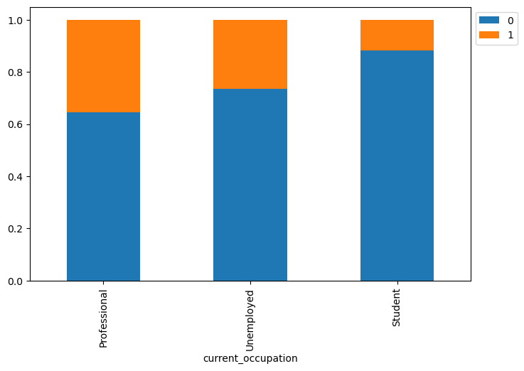

```python
stacked_barplot(data, "current_occupation", "status")
```

**Age can be a good factor to differentiate between such leads**

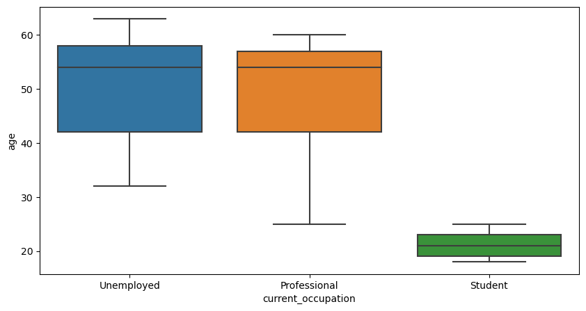

```python
plt.figure(figsize=(10, 5))
sns.boxplot(data = data, x = data["current_occupation"], y = data["age"])
plt.show()
```

```python
data.groupby(["current_occupation"])["age"].describe()
```

| current_occupation | count | mean | std | min | 25% | 50% | 75% | max |
| --- | --- | --- | --- | --- | --- | --- | --- | --- |
| Professional | 2616.00000 | 49.34748 | 9.89074 | 25.00000 | 42.00000 | 54.00000 | 57.00000 | 60.00000 |
| Student | 555.00000 | 21.14414 | 2.00111 | 18.00000 | 19.00000 | 21.00000 | 23.00000 | 25.00000 |
| Unemployed | 1441.00000 | 50.14018 | 9.99950 | 32.00000 | 42.00000 | 54.00000 | 58.00000 | 63.00000 |

This code is telling Python to find the values of 'age' and group the values by the column 'current_occupation' from the data dataframe. The describe() code tells Python to display the summary statistics for this subgroup

**The company's first interaction with leads should be compelling and persuasive. Let's see if the channels of the first interaction have an impact on the conversion of leads**

```
status                0     1   All
first_interaction
All                3235  1377  4612
Website            1383  1159  2542
Mobile App         1852   218  2070
------------------------------------------------------------------------------------------------------------------------
```

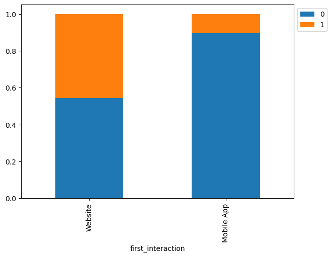

```python
#Visualize the relationship between 'first_interaction' and 'status'
stacked_barplot(data, "first_interaction", "status")
```

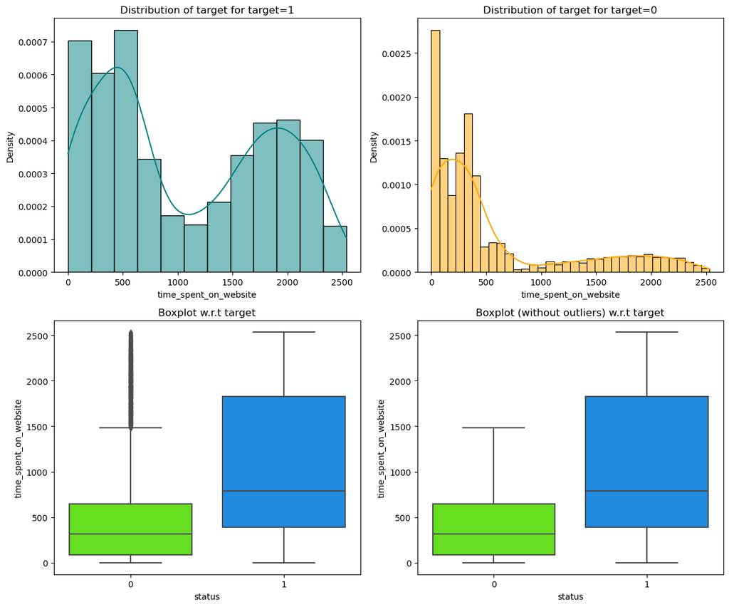

```python
distribution_plot_wrt_target(data, "time_spent_on_website", "status")
```

```python
# Find the median value
data.groupby(["status"])["time_spent_on_website"].median()
```

```
status
0   317.00000
1   789.00000
Name: time_spent_on_website, dtype: float64
```

This code is asking Python to find the median value of 'time_spent_on_website and group the results by the different values for 'status' from the data dataframe

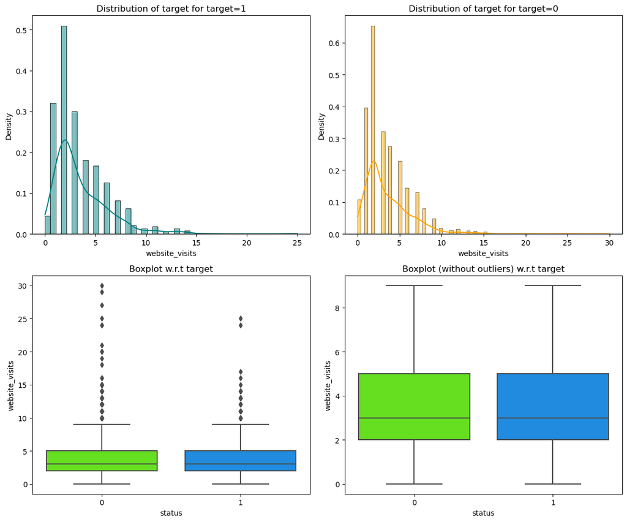

```python
distribution_plot_wrt_target(data, "website_visits", "status")
```

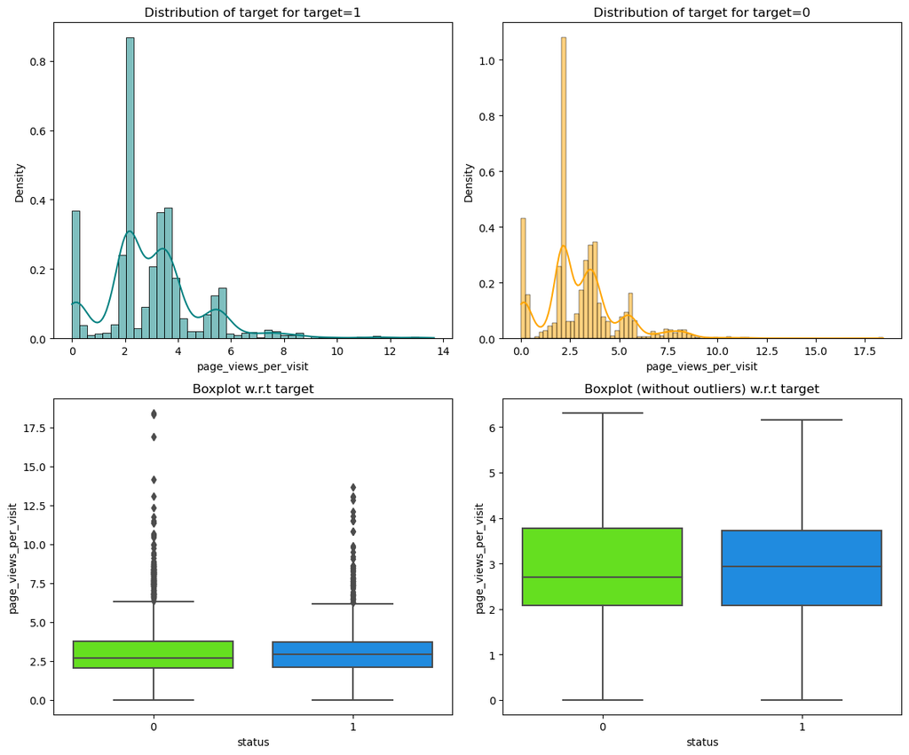

```python
distribution_plot_wrt_target(data, "page_views_per_visit", "status")
```

**People browsing the website or the mobile app are generally required to create a profile by sharing their personal details before they can access more information. Let's see if the profile completion level has an impact on lead status**

```
status                0     1   All
profile_completed
All                3235  1377  4612
High               1318   946  2264
Medium             1818   423  2241
Low                  99     8   107
------------------------------------------------------------------------------------------------------------------------
```

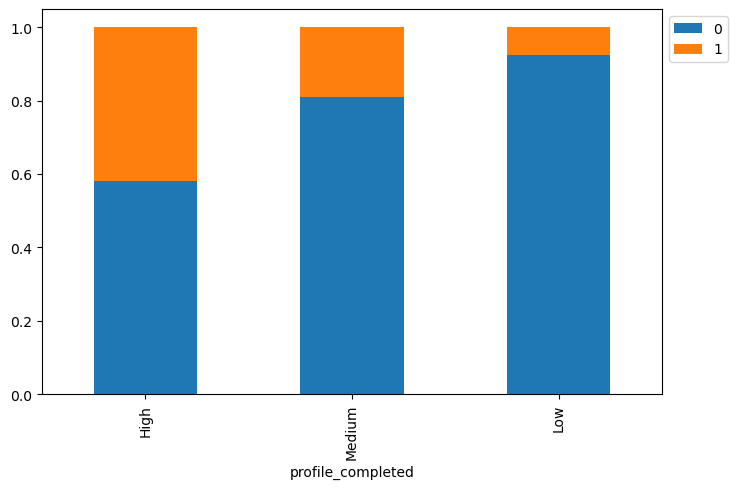

```python
stacked_barplot(data, "profile_completed", "status")
```

**After a lead shares their information by creating a profile, there may be interactions between the lead and the company to proceed with the process of enrollment. Let's see how the last activity impacts lead conversion status**

```
status               0     1   All
last_activity
All               3235  1377  4612
Email Activity    1587   691  2278
Website Activity   677   423  1100
Phone Activity     971   263  1234
------------------------------------------------------------------------------------------------------------------------
```

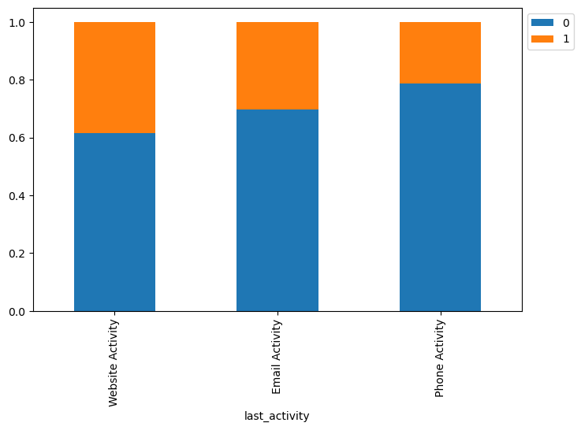

```python
stacked_barplot(data, "last_activity", "status")
```

**Let's see how advertisement and referrals impact the lead status**

```
status                0     1   All
print_media_type1
All                3235  1377  4612
No                 2897  1218  4115
Yes                 338   159   497
------------------------------------------------------------------------------------------------------------------------
```

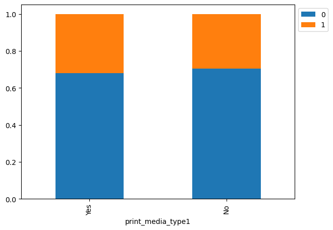

```python
stacked_barplot(data, "print_media_type1", "status")
```

```
status                0     1   All
print_media_type2
All                3235  1377  4612
No                 3077  1302  4379
Yes                 158    75   233
------------------------------------------------------------------------------------------------------------------------
```

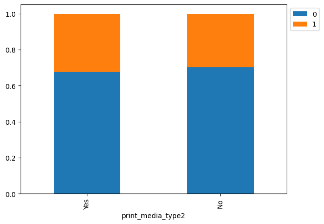

```python
stacked_barplot(data, "print_media_type2", "status")
```

```
status            0     1   All
digital_media
All            3235  1377  4612
No             2876  1209  4085
Yes             359   168   527
------------------------------------------------------------------------------------------------------------------------
```

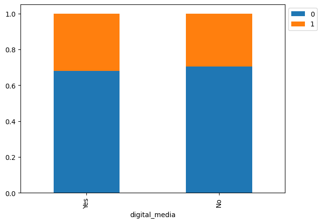

```python
stacked_barplot(data, "digital_media", "status")
```

```
status                   0     1   All
educational_channels
All                   3235  1377  4612
No                    2727  1180  3907
Yes                    508   197   705
------------------------------------------------------------------------------------------------------------------------
```

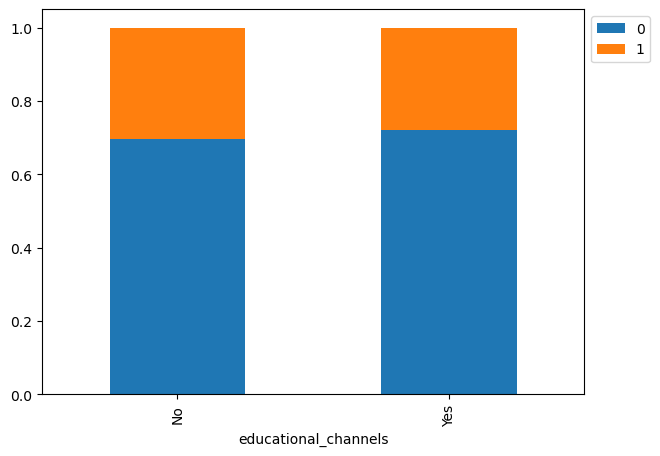

```python
stacked_barplot(data, "educational_channels", "status")
```

```
status       0     1   All
referral
All       3235  1377  4612
No        3205  1314  4519
Yes         30    63    93
------------------------------------------------------------------------------------------------------------------------
```

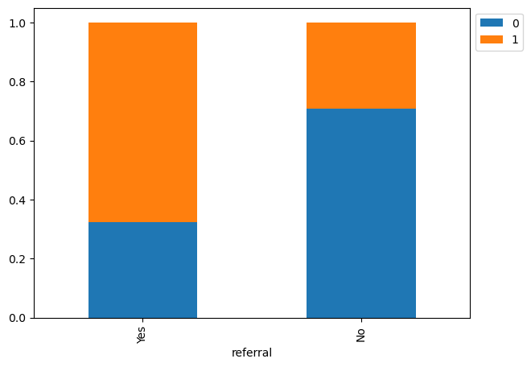

```python
stacked_barplot(data, "referral", "status")
```

### Outlier Check

- Let's check for outliers in the data.

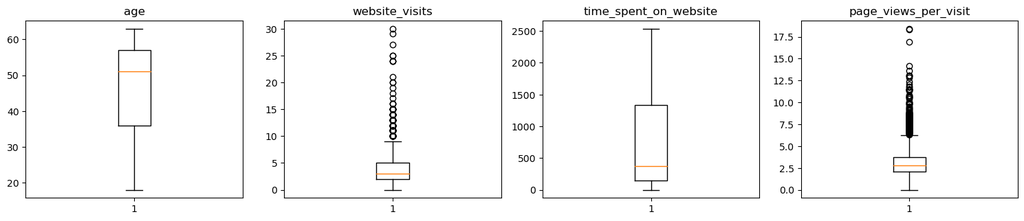

```python
numeric_columns = data.select_dtypes(include=np.number).columns.tolist()

numeric_columns.remove("status")

plt.figure(figsize=(15, 12))

for i, variable in enumerate(numeric_columns):
    plt.subplot(4, 4, i + 1)
    plt.boxplot(data[variable], whis=1.5)
    plt.tight_layout()
    plt.title(variable)

plt.show()
```

Explain the code:

This code tells Python to select the columns in the dataset that have the types that are considered numerical (integers, floats). The code then takes that list of values and converts it to a list. The list is then entered into a column that is called numerical_column.

The values within this column for 'status' are removed since they are not relevent for this analysis.

The remaining part of the code tells Python the parameters for constructing and visualizing the plot

**Observations:**_****

The results show that there are outliers present in both the website_visits variable and the page_views_per_visit variable

### Data Preparation for modeling

- We want to predict which lead is more likely to be converted.
- Before we proceed to build a model, we'll have to encode categorical features.
- We'll split the data into train and test to be able to evaluate the model that we build on the train data.

```python
X = data.drop(["status"], axis=1)
Y = data["status"]

X = pd.get_dummies(X, drop_first=True)


X_train, X_test, y_train, y_test = train_test_split(
    X, Y, test_size=0.30, random_state=1
)
```

The first part of this code tells Python to drop the column 'status' from the dataframe. (axis =1 indicates a column vs. a row) The next part is taking the data that was just dropped and adding it into a new column called Y

The dummy function is used to create numerical values for categorical variables. This code is telling Python to make "dummy" numerical variables for the categorical variables in the dataframe X (columns with status dropped)

The next part splits the data into train and test sets with X being the features (independent variables) and Y being the target (dependent) variable.

The 0.30 indicates that 30% of the data will be used for testing and 70% will be used for training

```python
print("Shape of Training set : ", X_train.shape)
print("Shape of test set : ", X_test.shape)
print("Percentage of classes in training set:")
print(y_train.value_counts(normalize=True))
print("Percentage of classes in test set:")
print(y_test.value_counts(normalize=True))
```

```
Shape of Training set :  (3228, 16)
Shape of test set :  (1384, 16)
Percentage of classes in training set:
0   0.70415
1   0.29585
Name: status, dtype: float64
Percentage of classes in test set:
0   0.69509
1   0.30491
Name: status, dtype: float64
```

This summarizes the split of the training and testing data

## **Building Classification Models**

### Model evaluation criterion

### Model can make wrong predictions as:

1. Predicting a lead will not be converted to a paid customer in reality, the lead would have converted to a paid customer.
2. Predicting a lead will be converted to a paid customer in reality, the lead would not have converted to a paid customer.

### Which case is more important?

- If we predict that a lead will not get converted and the lead would have converted then the company will lose a potential customer.
- If we predict that a lead will get converted and the lead doesn't get converted the company might lose resources by nurturing false-positive cases.

Losing a potential customer is a greater loss.

### How to reduce the losses?

- Company would want `Recall` to be maximized, greater the Recall score higher are the chances of minimizing False Negatives.

#### First, let's create functions to calculate different metrics and confusion matrix so that we don't have to use the same code repeatedly for each model.

```python
# Write a function to print the classification report and create a confusion matrix

def metrics_score(actual, predicted):
    print(classification_report(actual, predicted))

    cm = confusion_matrix(actual, predicted)

    plt.figure(figsize = (8, 5))

    sns.heatmap(cm, annot = True,  fmt = '.2f', xticklabels = ['Not Converted', 'Converted'], yticklabels = ['Not Converted', 'Converted'])

    plt.ylabel('Actual')

    plt.xlabel('Predicted')

    plt.show()
```

This code tells Python to create a classification report. A classification report contains the precision, recall, F-1 score for each class. The report will compare the performance of the actual values with the predicted values. This will show how well the model is performing and if any further tuning or adjustments are needed

The second part of the code tells Python to use the heatmap visual to visualize the confusion matrix. This matrix will visualize the number of True Positive, True Negative, False Positive, and False Negative results of the model.

## Decision Tree

### Building Decision Tree Model

```python
# Add the decision tree classifier to the training data
model_dt = DecisionTreeClassifier(random_state=1)
model_dt.fit(X_train, y_train)
```

```
DecisionTreeClassifier(random_state=1)
```

#### Checking model performance on training set

```
              precision    recall  f1-score   support

           0       1.00      1.00      1.00      2273
           1       1.00      1.00      1.00       955

    accuracy                           1.00      3228
   macro avg       1.00      1.00      1.00      3228
weighted avg       1.00      1.00      1.00      3228
```

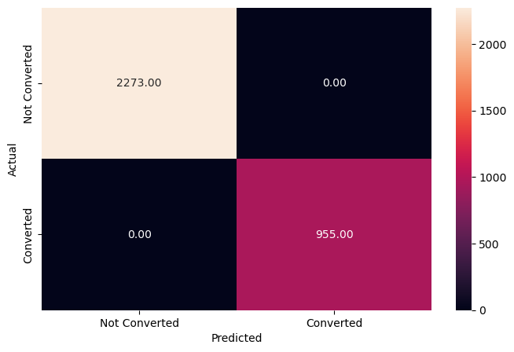

```python
# Check the performance of the training data
y_pred_train1 = (model_dt.predict(X_train))

metrics_score(y_train, y_pred_train1)
```

**Observations:**_****

The results indicate that this model is overfitting the data. This means that the parameters are not specific enough to differenciate between a true result and a negative result. The model needs to be tuned.

**Let's check the performance on test data to see if the model is overfitting.**

```
              precision    recall  f1-score   support

           0       0.87      0.86      0.86       962
           1       0.69      0.70      0.70       422

    accuracy                           0.81      1384
   macro avg       0.78      0.78      0.78      1384
weighted avg       0.81      0.81      0.81      1384
```

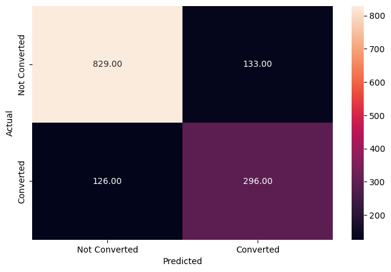

```python
# Checking performance on the testing data
y_pred_test1 = (model_dt.predict(X_test))

metrics_score(y_test, y_pred_test1)
```

**Observations:**_****

The testing data shows a low Recall of 70%. This means that the model is predicting the true positives only 70% of the time. In other words, only 70% of the ideal candidates for ExtraaLearn are fitting the prediction. GridSearchCV and Hypertuning were used find a more optimal profile for ExtraaLearn

**Let's try hyperparameter tuning using GridSearchCV to find the optimal max_depth** to reduce overfitting of the model. We can tune some other hyperparameters as well.